# 09_analysis_lm_alcohol

Authors

Asta Zeuner - s203544 - azeuner

Astrid Ginnerup - s203523 - AGinnerup

Emma Danø - s203564 - EDanoe

Andrea Kristensen - s193769 - AndreaMTK

Yayi Wang - s243554 - Yayi0117

# Analysis of Head and Neck Squamous Cell Carcinomas Data

## Load libraries

```r
library("tidyverse")
library("table1")
library("here")
```

## Download data

The data is from UCSC Xena. The data is from a cohort study, GDC TGGA Head and Neck Cancer (HNSC).

Code for downloading the datasets we will be working with and saving in data/_raw/ folder.

```r
raw_dir <- here("data/_raw/")
data_file <- "TCGA-HNSC.protein.tsv.gz"
data_loc <- "https://gdc-hub.s3.us-east-1.amazonaws.com/download/"

if( !dir.exists(raw_dir) ){
  dir.create(path = raw_dir)
}
if( !file.exists(str_c(raw_dir, data_file)) ){
  download.file(
    url = str_c(data_loc, data_file),
    destfile = str_c(raw_dir, data_file))
}
```

```r
raw_dir <- here("data/_raw/")
data_file <- "TCGA-HNSC.survival.tsv.gz"
data_loc <- "https://gdc-hub.s3.us-east-1.amazonaws.com/download/"

if( !dir.exists(raw_dir) ){
  dir.create(path = raw_dir)
}
if( !file.exists(str_c(raw_dir, data_file)) ){
  download.file(
    url = str_c(data_loc, data_file),
    destfile = str_c(raw_dir, data_file))
}
```

```r
raw_dir <- here("data/_raw/")
data_file <- "TCGA-HNSC.clinical.tsv.gz"
data_loc <- "https://gdc-hub.s3.us-east-1.amazonaws.com/download/"

if( !dir.exists(raw_dir) ){
  dir.create(path = raw_dir)
}
if( !file.exists(str_c(raw_dir, data_file)) ){
  download.file(
    url = str_c(data_loc, data_file),
    destfile = str_c(raw_dir, data_file))
}
```

## Load data

We are downloading 3 files form the Head and Neck Cancer cohort:

- **Protein expression data:** this is a dataset including the expression levels for the different proteins in the tissue samples, for the different patients. The expression levels are obtained using RPPA, with healthy tissue samples as control. Thus the expression levels are normalized values compared to a healthy sample.
- **Survival data**: this is a dataset including the survival status of the patients, including the number of days they survived after diagnosis, if they are not dead it is the number of days from diagnosis till last chek up.
- **Clinical data:** this is meta data about patients in the study, including age, alcohol history etc

read_tsv is used to load data files from data/_raw and saving the files in objects.

```r
protein_data <- read_tsv(file = here("data/_raw/TCGA-HNSC.protein.tsv.gz"))
survival_data <- read_tsv(file = here("data/_raw/TCGA-HNSC.survival.tsv.gz"))
clinical_data <- read_tsv(file = here("data/_raw/TCGA-HNSC.clinical.tsv.gz"))
```

## Join meta data: Clinical and survival data

The clinical_and survival_data are joined using inner_join() to create a meta_data set. The joined meta_data is saved as a .tsv.gz file in data folder.

```r
meta_data <- inner_join(clinical_data, survival_data, by = c("sample" = "sample"))

data_dir <- here("data/")

write_tsv(x = meta_data,
          file = str_c(data_dir,
                       "01_meta_data_load.tsv.gz"))
```

## Joining meta_data and protein expression

The protein_data is pivoted longer using pivot_longer()

```r
peptide_long <- protein_data |>
                pivot_longer(cols = -1,
                             names_to = "sample",
                             values_to = "expression")
```

meta_data and protein_long datasets are then joined using inner_join(). The resulting dataset is saved as a .tsv.gz file in data folder and will be the dataset used for cleaning the data.

```r
# Join the datasets on the 'sample' column

expression_meta_data <- inner_join(meta_data,
                         peptide_long,
                         by = "sample")

data_dir <- here("data/")


write_tsv( x = expression_meta_data,
           file = str_c(data_dir,
                        "01_expression_meta_data_load.tsv.gz"))
```

# Cleaning the data

## Load libraries

```r
library("tidyverse")
library("table1")
library("here")
```

## Load dataset

Loading the dataset into an object.

```r
expression_meta_data_clean <- read_tsv(file = here("data/01_expression_meta_data_load.tsv.gz"))
```

## Cleaning the data

To clean the dataset, we select the variables we want to work with and assign new names to the variables so they follow snake_case. Additionally we use the select to relocate the variables in the order we want them.  
The cleaned dataset is assigned to a new object.

```r
expression_meta_data_clean <- expression_meta_data_clean |>
  select(sample_id = sample,
         gender = gender.demographic,
         race = race.demographic,
         vital_status = vital_status.demographic,
         overall_survival = OS,
         primary_site,
         pathologic_stage = ajcc_pathologic_stage.diagnoses,
         age_at_index = age_at_index.demographic,
         year_of_birth = year_of_birth.demographic,
         year_of_death = year_of_death.demographic,
         tissue_source_location = name.tissue_source_site,
         cigarettes_per_day = cigarettes_per_day.exposures,
         years_smoked = years_smoked.exposures,
         alcohol_history = alcohol_history.exposures,
         peptide_target,
         expression)
```

Then we trim the sample_ID to not contain the code TCGA standing for The Cancer Genome Atlas, as all the values comes from this data and has this code in the beginning.

```r
expression_meta_data_clean <- expression_meta_data_clean |>
  mutate(sample_id = sub("^TCGA-(.*)", "\\1", sample_id))
```

## Write the clean dataset to a tsv.gz file

The clean dataset is saved as a .tsv.gz file in data folder and will be the dataset used for augmenting the data.

```r
data_dir <- here("data/")

write_tsv( x = expression_meta_data_clean,
           file = str_c(data_dir,
                  "02_expression_meta_data_clean.tsv.gz"))
```

# Augmenting the data

## Load libraries

```r
library("tidyverse")
library("table1")
library("here")
```

## Loading the data

The cleaned data is loaded into a new object.

```r
expression_meta_data_aug <- read_tsv(file = here("data/02_expression_meta_data_clean.tsv.gz"))
```

## Creating new variables and adding them to the dataset

### Patient ID

A new variable called patient_id is created from sample_id using mutate().

```r
expression_meta_data_aug <- expression_meta_data_aug |>
  mutate(patient_id = sub("(.*)-..", "\\1", sample_id)) |>
  relocate(patient_id, .before = sample_id)
```

### 5 and 10 years age intervals

Adding new variables with 5 and 10 year age intervals to the data using mutate() and saving in a new object. cut() is used to divide age_at_index into intervals of 5 years specified by breaks. Lables to represent each interval are created and ages at the lower boundary are included.

```r
expression_meta_data_aug <- expression_meta_data_aug |>
  mutate(age_interval_5_year = cut(age_at_index,
                                   breaks = seq(0, 100, by = 5),
                                   labels = paste(seq(0, 95, by = 5),
                                                  seq(5, 100, by = 5) - 1,
                                                  sep = "-"),
                                   include.lowest = TRUE),
          age_interval_10_year = cut(age_at_index,
                                     breaks = seq(0, 100, by = 10),
                                     labels = paste(seq(0, 90, by = 10),
                                                    seq(10, 100, by = 10) - 1,
                                                    sep = "-"),
                                     include.lowest = TRUE)) |>

  relocate(age_interval_5_year, .after = age_at_index) |>
  relocate(age_interval_10_year, .after = age_interval_5_year) # Moving the age_interval columns to after age_at_index
```

### Mean expression of peptide_target

Adding a variable for the mean expression of each peptide_target using group_by() and mutate().

```r
expression_meta_data_aug <- expression_meta_data_aug |>
  group_by(peptide_target) |>
  mutate(mean_expression = mean(expression, na.rm = TRUE)) |>
  ungroup() # Removing the grouping to ensure that the following work is not messed up
```

### Mean expression of each peptide_target for each pathologic state

Mean expressions of each peptide_target grouped by the pathologic_stage are calculated. NA’s are excluded.  
The table is then widened with the new variables with the calculated mean named by the pathological_state using pivot_wider(). This is saved in a new object.

The mean expressions are then added to the dataset using right_join().

```r
# Calculate the mean for each pathologic stage
mean_of_expression_pathologic_stages <- expression_meta_data_aug |>
  filter(!is.na(pathologic_stage)) |>
  group_by(peptide_target, pathologic_stage) |>
  summarise(mean_expression = mean(expression, na.rm = TRUE), .groups = "drop") |>
  pivot_wider(names_from = pathologic_stage,
              values_from = mean_expression,
              names_prefix = "mean_expression_")

# Join the calculated means back into the original dataset with the join function
expression_meta_data_aug <- expression_meta_data_aug |>
  right_join(mean_of_expression_pathologic_stages, by = "peptide_target")
```

### Adding alcohols history as a binomial factor (0 and 1)

```r
expression_meta_data_aug <- expression_meta_data_aug |>
  mutate(alcohol_history_binomial = case_when(alcohol_history == "No" ~ 0,
                                              alcohol_history == "Yes" ~ 1)) |>
  relocate(alcohol_history_binomial, .after = alcohol_history)
```

## Write the augmented dataset to a tsv.gz file

The augmented dataset is saved as a .tsv.gz file in data folder and will be the dataset used for description, analysis and modeling.

```r
data_dir <- here("data/")

write_tsv( x = expression_meta_data_aug,
           file = str_c(data_dir,
                  "03_expression_meta_data_aug.tsv.gz"))
```

# Description

## Load library

```r
library("tidyverse")
library("table1")
library("here")
```

## Loading the data

```r
expression_meta_data_load <- read_tsv(file = here("data/01_expression_meta_data_load.tsv.gz"))

expression_meta_data_aug <- read_tsv(file = here("data/03_expression_meta_data_aug.tsv.gz"))
```

## Description

First of all, check tables before and after cleaning and augmentation. We can see that the columns changed.

```r
columns_before <- expression_meta_data_load |> ncol()
columns_after <- expression_meta_data_aug |> ncol()

columns_before
```

```
[1] 98
```

```r
columns_after
```

```
[1] 26
```

After cleaning and augmentation, we have 26 columns to analyze:

```r
columns_names_after <- expression_meta_data_aug |> colnames()

columns_names_after
```

```
 [1] "patient_id"                "sample_id"
 [3] "gender"                    "race"
 [5] "vital_status"              "overall_survival"
 [7] "primary_site"              "pathologic_stage"
 [9] "age_at_index"              "age_interval_5_year"
[11] "age_interval_10_year"      "year_of_birth"
[13] "year_of_death"             "tissue_source_location"
[15] "cigarettes_per_day"        "years_smoked"
[17] "alcohol_history"           "alcohol_history_binomial"
[19] "peptide_target"            "expression"
[21] "mean_expression"           "mean_expression_Stage I"
[23] "mean_expression_Stage II"  "mean_expression_Stage III"
[25] "mean_expression_Stage IVA" "mean_expression_Stage IVB"
```

We can see that patient numbers did not change from the following code.

```r
n_patient_before <- expression_meta_data_load |>
  select(submitter_id) |>
  n_distinct()

n_patient_after <- expression_meta_data_aug |>
  select(patient_id) |>
  n_distinct()


n_patient_before
```

```
[1] 353
```

```r
n_patient_after
```

```
[1] 353
```

Check the different pathologic stages and how patients are distributed among these groups.

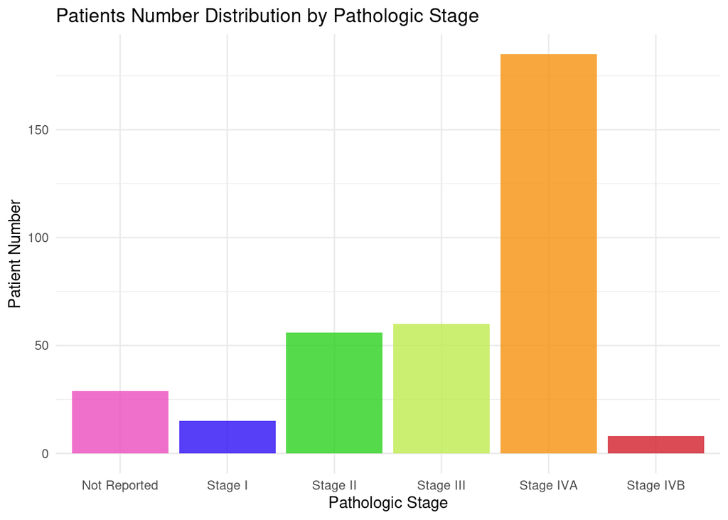

```r
pathologic_stage_distribution <- expression_meta_data_aug |>
  mutate(pathologic_stage = replace_na(pathologic_stage, "Not Reported")) |>
  group_by(pathologic_stage) |>
  summarize(n_patients = n_distinct(patient_id)) |>

  ggplot(aes(x = pathologic_stage,
             y = n_patients,
             fill = pathologic_stage)) +
  geom_bar(stat = "identity",
           alpha = 0.8) +
  labs(title = "Patients Number Distribution by Pathologic Stage",
       x = "Pathologic Stage",
       y = "Patient Number") +
  theme_minimal() +
  theme(legend.position = "none") +
  scale_fill_manual(values = c(
    "Not Reported" = "#eb4cbe",
    "Stage I" = "#2d0ef5",
    "Stage II" = "#2bd11f",
    "Stage III" = "#beeb4c",
    "Stage IVA" = "#f5910e",
    "Stage IVB" = "#d11f2b"
  ))

pathologic_stage_distribution
```

```r
ggsave(filename = "04_pathologic_stage_distribution.png",
       plot = pathologic_stage_distribution,
       device = "png",
       path = "../results/images")
```

Check the mean and middle values of patients’ age.

```r
expression_meta_data_aug |>
  summarize(
    mean_age = mean(age_at_index, na.rm = TRUE),   # Mean age
    middle_age = median(age_at_index, na.rm = TRUE) # Median age
  )
```

```
# A tibble: 1 × 2
  mean_age middle_age
     <dbl>      <dbl>
1     61.1         61
```

Check the age distribution of patients and stratified on vital_status

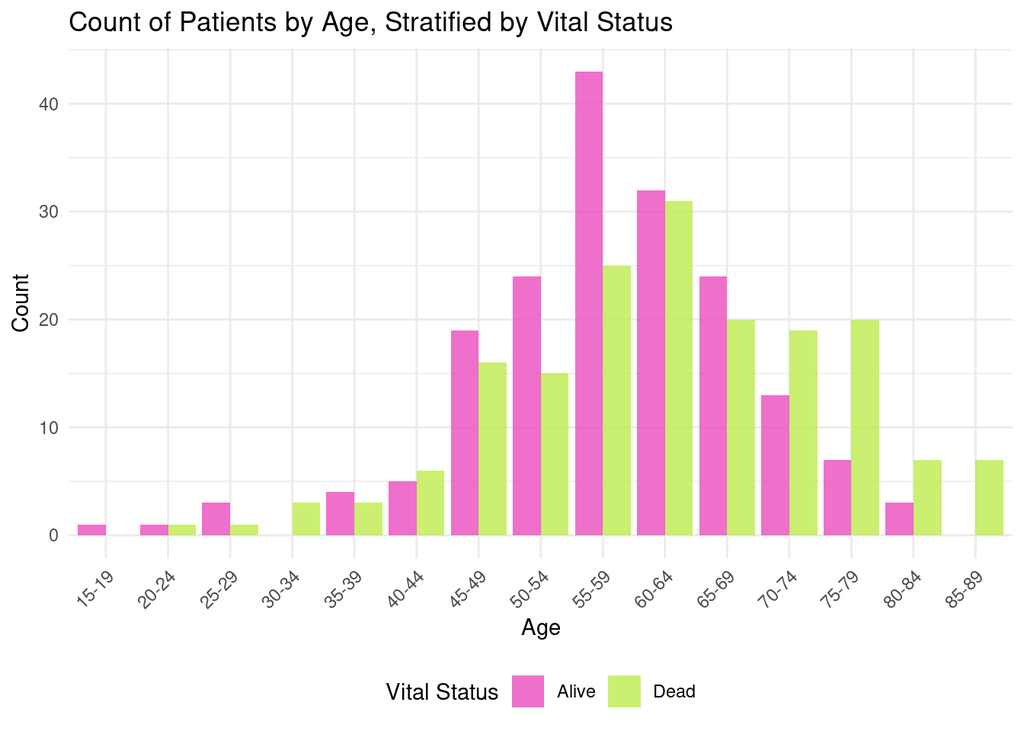

```r
vital_status_age_distribution <- expression_meta_data_aug |>
  group_by(vital_status,
           age_interval_5_year) |>
  summarize(n = n_distinct(patient_id),
            .groups = "drop") |> # Drop grouping
  complete(age_interval_5_year,
           vital_status,
           fill = list(n = 0)) |> # Fill missing combinations

  ggplot(aes(x = age_interval_5_year, y = n, fill = vital_status)) +
  geom_bar(stat = "identity", position = "dodge",alpha = 0.8) +
  scale_fill_manual(values = c("Alive" = "#eb4cbe", "Dead" = "#beeb4e")) +
  labs(
    title = "Count of Patients by Age, Stratified by Vital Status",
    x = "Age",
    y = "Count",
    fill = "Vital Status"
  ) +
  theme_minimal() +
  theme(axis.text.x = element_text(angle = 45, hjust = 1),
        legend.position = "bottom")

vital_status_age_distribution
```

```r
ggsave(filename = "04_vital_status_age_distribution.png",
       plot = vital_status_age_distribution,
       device = "png",
       path = "../results/images")
```

Check how many peptides we have:

```r
n_peptides <- expression_meta_data_aug |>
  select(peptide_target) |>
  n_distinct()

n_peptides
```

```
[1] 487
```

# Analysis: Heatmap most up and down regulated proteins

## Load libraries

```r
library("tidyverse")
library("table1")
library("here")
```

## Loading the data

```r
expression_meta_data_analysis <- read_tsv(file = here("data/03_expression_meta_data_aug.tsv.gz"))
```

### Heat-map of 20 most up- and downregulated peptide-targets plotted against age

```r
# Select top 20 most upregulated peptide targets
most_upregulated <- expression_meta_data_analysis |>

  filter(!is.na(mean_expression)) |> # Removing rows with NA

  group_by(peptide_target) |>

  summarize(mean_expression = mean(expression, na.rm = TRUE), .groups = "drop") |> # Summarizing the mean_expression even though having a variable of this name, as it requires less coding in this way

  slice_max(order_by = mean_expression, n = 20)



# Select bottom 20 most downregulated
most_downregulated <- expression_meta_data_analysis |>

  filter(!is.na(expression)) |>  # Removing rows with NA

  group_by(peptide_target) |>

  summarize(mean_expression = mean(expression, na.rm = TRUE), .groups = "drop") |>

  slice_min(order_by = mean_expression, n = 20)

# Combine the two subsets
selected_peptides <- bind_rows(most_downregulated, most_upregulated)

# Inspect data
selected_peptides
```

```
# A tibble: 40 × 2
   peptide_target      mean_expression
   <chr>                         <dbl>
 1 ERALPHA                      -1.84
 2 EMA                          -1.68
 3 TTF1                         -1.29
 4 PAR                          -1.15
 5 RBM15                        -0.873
 6 53BP1                        -0.864
 7 ACETYLATUBULINLYS40          -0.838
 8 PLC-gamma1                   -0.811
 9 ATRX                         -0.747
10 ATM                          -0.717
# ℹ 30 more rows
```

```r
# Extract the peptide_target levels for ordering in the heatmap
peptide_target_levels <- selected_peptides |>

  pull(peptide_target)  # Pull the peptide_target column as a vector

peptide_target_levels
```

```
 [1] "ERALPHA"             "EMA"                 "TTF1"
 [4] "PAR"                 "RBM15"               "53BP1"
 [7] "ACETYLATUBULINLYS40" "PLC-gamma1"          "ATRX"
[10] "ATM"                 "GAB2"                "AKT_pS473"
[13] "U-Histone-H2B"       "AR"                  "Wee1"
[16] "XPA"                 "BRD4"                "ACSL1"
[19] "HER2"                "FASN"                "NDRG1_pT346"
[22] "IDO"                 "CAVEOLIN1"           "LAD1"
[25] "ANNEXIN1"            "PAI1"                "EGFR_pY1068"
[28] "HER2_pY1248"         "Connexin-43"         "EPPK1"
[31] "SRC_pY416"           "ATM_pS1981"          "Cox2"
[34] "P38_pT180Y182"       "SOD2"                "HSP27_pS82"
[37] "CD44"                "MCT4"                "EphA2_pS897"
[40] "VEGFR2"
```

```r
# Filter the main dataset for the selected peptides and arrange by mean_expression in descending order
heatmap_selected_peptides <- expression_meta_data_analysis |>

  filter(!age_interval_5_year %in% c("15-19", "20-24")) |>

  semi_join(selected_peptides, by = "peptide_target") |>  # Keep rows with matching peptide_target

  filter(!is.na(mean_expression)) |>  # Removing all NAs

  group_by(peptide_target, age_interval_5_year) |>

  summarize(
    mean_expression = mean(expression, na.rm = TRUE),  # Calculate mean expression
    .groups = "drop") |>   # Drop grouping after summarization

  arrange(desc(desc(mean_expression)))   # Sort by mean_expression, highest to lowest


heatmap_selected_peptides
```

```
# A tibble: 520 × 3
   peptide_target age_interval_5_year mean_expression
   <chr>          <chr>                         <dbl>
 1 EMA            25-29                         -2.17
 2 EMA            40-44                         -2.16
 3 EMA            45-49                         -2.15
 4 ERALPHA        80-84                         -2.02
 5 ERALPHA        30-34                         -1.99
 6 ERALPHA        40-44                         -1.93
 7 ERALPHA        75-79                         -1.88
 8 ERALPHA        65-69                         -1.87
 9 EMA            80-84                         -1.86
10 ERALPHA        50-54                         -1.86
# ℹ 510 more rows
```

```r
# Create the heatmap
heatmap <- heatmap_selected_peptides |>

  ggplot(aes(
    x = factor(peptide_target, levels = peptide_target_levels),  # Use the extracted levels vector
    y = age_interval_5_year,
    fill = mean_expression
  )) +

  # Heatmap tiles
  geom_tile(color = "white") +

  # Color gradient for expression
  scale_fill_gradient2(
    low = "#2d0ef5",
    mid = "white",
    high = "#d11f2b",
    na.value = "black"
  ) +

  # Labels
  labs(
    title = "Heatmap of Expression Across Age Intervals and 20 Most Upregulated and 20 Most Downregulated Peptide Targets",
    x = "Peptide Target",
    y = "Age Interval",
    fill = "Mean Expression"
  ) +

  # Themes
  theme(
    # Axis text size
    axis.text.x = element_text(angle = 60, hjust = 1, size = 15),
    axis.text.y = element_text(size = 15),

    # Title and axis label sizes
    plot.title = element_text(size = 20, face = "bold", hjust = 0.5),
    axis.title.x = element_text(size = 18),
    axis.title.y = element_text(size = 18),

    # Legend position and text size
    legend.position = "right",
    legend.text = element_text(size = 12),
    legend.title = element_text(size = 14)
  )
```

```r
ggsave(
  filename = "05_analysis_heatmap.png",
  plot = heatmap,   # Pass the ggplot object, not the data frame
  device = "png",
  path = "../results/images",
  width = 20,
  height = 10
)
```

```r
selected_peptides_random <- expression_meta_data_analysis |>

  filter(!is.na(expression)) |>  # Remove rows with NA expression

  distinct(peptide_target) |>  # Ensure unique peptide targets

  sample_n(40)  # Randomly sample 40 targets
```

```r
# Extract the peptide_target levels for ordering in the heatmap
peptide_target_levels_random <- selected_peptides_random |>

  pull(peptide_target)  # Pull the peptide_target column as a vector
```

```r
heatmap_selected_peptides_random <- expression_meta_data_analysis |>

  filter(!age_interval_5_year %in% c("15-19", "20-24")) |>

  semi_join(selected_peptides_random, by = "peptide_target") |>  # Keep rows with matching peptide_target

  filter(!is.na(expression), !is.na(age_interval_5_year)) |>  # Removing all NAs

  group_by(peptide_target, age_interval_5_year) |>  # Group by peptide_target and age_interval_5_year

  summarize(
    mean_expression = mean(expression, na.rm = TRUE),  # Calculate mean expression
    .groups = "drop"  # Drop grouping after summarization
  )
```

```r
# Create the heatmap
heatmap_selected_peptides_random |>
  ggplot(aes(
    x = factor(peptide_target, levels = peptide_target_levels_random),  # Use the extracted levels vector
    y = age_interval_5_year,
    fill = mean_expression
  )) +

  # Heatmap tiles
  geom_tile(color = "white") +

  # Color gradient for expression
  scale_fill_gradient2(
    low = "blue",
    mid = "white",
    high = "red",
    na.value = "black"
  ) +

  # Labels
  labs(
    title = "Heatmap of Expression Across Age Intervals for 40 Randomly Selected Peptide Targets",
    x = "Peptide Target",
    y = "Age Interval",
    fill = "Mean Expression"
  ) +

  # Themes
  theme(
    # Axis text size
    axis.text.x = element_text(angle = 60, hjust = 1, size = 15),
    axis.text.y = element_text(size = 15),

    # Title and axis label sizes
    plot.title = element_text(size = 20, face = "bold", hjust = 0.5),
    axis.title.x = element_text(size = 18),
    axis.title.y = element_text(size = 18),

    # Legend position and text size
    legend.position = "bottom",
    legend.text = element_text(size = 12),
    legend.title = element_text(size = 14)
  )
```

We have decided to **leave out the bar plot of the five most up and downregulated genes for each pathologic stage** as we did not find it useful enough for our analysis.

```r
expression_meta_data_analysis_1 <- expression_meta_data_analysis |>

  rename(
    pathologic_stage_original = pathologic_stage,
    mean_expression_original = mean_expression
  )
```

```r
# Gather all stage columns into long format
expression_long <- expression_meta_data_analysis_1 |>
  pivot_longer(
    cols = starts_with("mean_expression_"),
    names_to = "pathologic_stage",
    values_to = "mean_expression"
  ) |>
  mutate(
    pathologic_stage = str_replace(pathologic_stage, "mean_expression_", "")  # Clean stage names
  )

# Identify the top 5 upregulated and bottom 5 downregulated genes for each stage
top_bottom_genes <- expression_long |>
  filter(!is.na(mean_expression)) |>
  group_by(pathologic_stage) |>
  slice_max(order_by = mean_expression, n = 5, with_ties = FALSE) |>  # Top 5 per stage
  bind_rows(
    expression_long |>
      filter(!is.na(mean_expression)) |>
      group_by(pathologic_stage) |>
      slice_min(order_by = mean_expression, n = 5, with_ties = FALSE)  # Bottom 5 per stage
  )

# Create the bar plot
top_bottom_genes |>
  ggplot(aes(x = reorder(peptide_target, mean_expression),
             y = mean_expression,
             fill = mean_expression > 0)) +
  geom_bar(stat = "identity", show.legend = FALSE) +
  facet_wrap(~ pathologic_stage, scales = "free_y") +  # One facet per stage
  scale_fill_manual(values = c("blue", "red")) +  # Red for upregulated, blue for downregulated
  labs(
    title = "Top 5 Upregulated and Downregulated Peptide Targets by Pathologic Stage",
    x = "Peptide Target",
    y = "Mean Expression"
  ) +
  theme_minimal() +
  theme(
    axis.text.x = element_text(angle = 45, hjust = 1, size = 10),
    axis.title = element_text(size = 14),
    strip.text = element_text(size = 12)
  )
```

# Analysis: Linear model on vital status

## Load libraries

```r
library("tidyverse")
library("broom")
library("ggthemes")
library("ggrepel")
library("here")
```

## Loading data

```r
expression_meta_data_aug <- read_tsv(file = here("data/03_expression_meta_data_aug.tsv.gz"))
```

# Linear model - dead or alive

## Selecting variables, grouping and nesting the data for the linear modelling

We want to make a linear model of the peptide expression levels and the overall survival. From this we can investigate if there are a difference in the expression levels of some proteins between patients who survives and patients who dies.

Selecting the variables that we want to use for the linear modeling. NA’s in “expression” are dropped, as we cannot make a linear model with missing expression values.

```r
expression_meta_data_lm_vital <- expression_meta_data_aug |>
  select(overall_survival,
         peptide_target,
         expression) |>
   drop_na(expression)

expression_meta_data_lm_vital
```

```
# A tibble: 161,195 × 3
   overall_survival peptide_target expression
              <dbl> <chr>               <dbl>
 1                1 1433BETA          -0.0974
 2                1 1433EPSILON       -0.0884
 3                1 1433ZETA           0.295
 4                1 4EBP1              0.236
 5                1 4EBP1_pS65        -0.332
 6                1 4EBP1_pT37T46     -0.209
 7                1 4EBP1_pT70        -0.0246
 8                1 53BP1             -0.644
 9                1 ACC_pS79          -0.590
10                1 ACC1              -0.119
# ℹ 161,185 more rows
```

Grouping the data by peptide_target and nesting the data so that each peptide_target gets a dataframe that contains the overall survival and the protein expression for all the patients.

```r
expression_meta_data_lm_vital_nested <- expression_meta_data_lm_vital |>
  group_by(peptide_target) |>
  nest()

expression_meta_data_lm_vital_nested
```

```
# A tibble: 469 × 2
# Groups:   peptide_target [469]
   peptide_target data
   <chr>          <list>
 1 1433BETA       <tibble [353 × 2]>
 2 1433EPSILON    <tibble [353 × 2]>
 3 1433ZETA       <tibble [353 × 2]>
 4 4EBP1          <tibble [353 × 2]>
 5 4EBP1_pS65     <tibble [353 × 2]>
 6 4EBP1_pT37T46  <tibble [353 × 2]>
 7 4EBP1_pT70     <tibble [353 × 2]>
 8 53BP1          <tibble [353 × 2]>
 9 ACC_pS79       <tibble [353 × 2]>
10 ACC1           <tibble [353 × 2]>
# ℹ 459 more rows
```

## Adding the linear model to the dataset

Adding the linear model to the data using mutate() and lm().

```r
expression_meta_data_lm_vital_nested_model <- expression_meta_data_lm_vital_nested |>
  mutate(model_object = map(.x = data,
                            .f = ~lm(formula = expression ~ overall_survival,
                                   data = .x)))

expression_meta_data_lm_vital_nested_model
```

```
# A tibble: 469 × 3
# Groups:   peptide_target [469]
   peptide_target data               model_object
   <chr>          <list>             <list>
 1 1433BETA       <tibble [353 × 2]> <lm>
 2 1433EPSILON    <tibble [353 × 2]> <lm>
 3 1433ZETA       <tibble [353 × 2]> <lm>
 4 4EBP1          <tibble [353 × 2]> <lm>
 5 4EBP1_pS65     <tibble [353 × 2]> <lm>
 6 4EBP1_pT37T46  <tibble [353 × 2]> <lm>
 7 4EBP1_pT70     <tibble [353 × 2]> <lm>
 8 53BP1          <tibble [353 × 2]> <lm>
 9 ACC_pS79       <tibble [353 × 2]> <lm>
10 ACC1           <tibble [353 × 2]> <lm>
# ℹ 459 more rows
```

Computing the confidence intervals and p-value based on th elinear model using the tidy()-function

```r
expression_meta_data_lm_vital_nested_model_tidy <- expression_meta_data_lm_vital_nested_model |>
  mutate(model_object_tidy = map(.x = model_object,
                                 .f = ~ tidy(conf.int = TRUE,
                                             conf.level = 0.95,
                                             x =.x)))

expression_meta_data_lm_vital_nested_model_tidy
```

```
# A tibble: 469 × 4
# Groups:   peptide_target [469]
   peptide_target data               model_object model_object_tidy
   <chr>          <list>             <list>       <list>
 1 1433BETA       <tibble [353 × 2]> <lm>         <tibble [2 × 7]>
 2 1433EPSILON    <tibble [353 × 2]> <lm>         <tibble [2 × 7]>
 3 1433ZETA       <tibble [353 × 2]> <lm>         <tibble [2 × 7]>
 4 4EBP1          <tibble [353 × 2]> <lm>         <tibble [2 × 7]>
 5 4EBP1_pS65     <tibble [353 × 2]> <lm>         <tibble [2 × 7]>
 6 4EBP1_pT37T46  <tibble [353 × 2]> <lm>         <tibble [2 × 7]>
 7 4EBP1_pT70     <tibble [353 × 2]> <lm>         <tibble [2 × 7]>
 8 53BP1          <tibble [353 × 2]> <lm>         <tibble [2 × 7]>
 9 ACC_pS79       <tibble [353 × 2]> <lm>         <tibble [2 × 7]>
10 ACC1           <tibble [353 × 2]> <lm>         <tibble [2 × 7]>
# ℹ 459 more rows
```

## Wrangling the expression data estimates

```r
expression_meta_data_lm_vital_estimates <- expression_meta_data_lm_vital_nested_model_tidy |>
  unnest(model_object_tidy)

expression_meta_data_lm_vital_estimates
```

```
# A tibble: 938 × 10
# Groups:   peptide_target [469]
   peptide_target data     model_object term        estimate std.error statistic
   <chr>          <list>   <list>       <chr>          <dbl>     <dbl>     <dbl>
 1 1433BETA       <tibble> <lm>         (Intercept)  0.0284    0.00985    2.89
 2 1433BETA       <tibble> <lm>         overall_su… -0.00132   0.0140    -0.0939
 3 1433EPSILON    <tibble> <lm>         (Intercept)  0.0838    0.0164     5.12
 4 1433EPSILON    <tibble> <lm>         overall_su… -0.00426   0.0233    -0.182
 5 1433ZETA       <tibble> <lm>         (Intercept)  0.554     0.0364    15.2
 6 1433ZETA       <tibble> <lm>         overall_su… -0.0169    0.0519    -0.326
 7 4EBP1          <tibble> <lm>         (Intercept)  0.499     0.0401    12.5
 8 4EBP1          <tibble> <lm>         overall_su… -0.116     0.0571    -2.04
 9 4EBP1_pS65     <tibble> <lm>         (Intercept) -0.179     0.0233    -7.66
10 4EBP1_pS65     <tibble> <lm>         overall_su…  0.0108    0.0332     0.324
# ℹ 928 more rows
# ℹ 3 more variables: p.value <dbl>, conf.low <dbl>, conf.high <dbl>
```

## Clean the data and calculating q.value

Term describes if the patient is dead or alive. 0 = alive and 1 = dead. Therefore the intercept is alive and the slope + intercept is dead. The slope is called Overall survival in the Term.

We are filtering for the term = “overall survival”, because then we get the difference between alive and dead.

Then we select the peptide_targets, p.value, estimate and confidence interval. To be able to analyse if there are significant differences between expression compared to their vital status.

```r
expression_meta_data_lm_vital_estimates_clean <- expression_meta_data_lm_vital_estimates |>
  filter(term == "overall_survival") |>
  select(peptide_target,
         p.value,
         estimate,
         conf.low,
         conf.high) |>
  ungroup(peptide_target)

expression_meta_data_lm_vital_estimates_clean
```

```
# A tibble: 469 × 5
   peptide_target p.value estimate conf.low conf.high
   <chr>            <dbl>    <dbl>    <dbl>     <dbl>
 1 1433BETA        0.925  -0.00132  -0.0289   0.0263
 2 1433EPSILON     0.855  -0.00426  -0.0502   0.0416
 3 1433ZETA        0.744  -0.0169   -0.119    0.0852
 4 4EBP1           0.0424 -0.116    -0.229   -0.00403
 5 4EBP1_pS65      0.746   0.0108   -0.0546   0.0761
 6 4EBP1_pT37T46   0.0822 -0.123    -0.261    0.0157
 7 4EBP1_pT70      0.0110 -0.0720   -0.127   -0.0166
 8 53BP1           0.867   0.00944  -0.101    0.120
 9 ACC_pS79        0.852   0.00817  -0.0777   0.0941
10 ACC1            0.302   0.0583   -0.0527   0.169
# ℹ 459 more rows
```

Adding the adjusted p-value in a new variable, q.value, and add extra variable that tells if the q-value is significant or not with alpha = 5%

```r
expression_meta_data_lm_vital_estimates_clean <- expression_meta_data_lm_vital_estimates_clean |>
  mutate(q.value = p.adjust(p = p.value),
         is_significant = case_when(q.value > 0.05 ~ "no",
                                    q.value <= 0.05 ~ "yes"),
         label = case_when(is_significant == "yes" ~ peptide_target,
                           is_significant == "no" ~ ""))

expression_meta_data_lm_vital_estimates_clean
```

```
# A tibble: 469 × 8
   peptide_target p.value estimate conf.low conf.high q.value is_significant
   <chr>            <dbl>    <dbl>    <dbl>     <dbl>   <dbl> <chr>
 1 1433BETA        0.925  -0.00132  -0.0289   0.0263        1 no
 2 1433EPSILON     0.855  -0.00426  -0.0502   0.0416        1 no
 3 1433ZETA        0.744  -0.0169   -0.119    0.0852        1 no
 4 4EBP1           0.0424 -0.116    -0.229   -0.00403       1 no
 5 4EBP1_pS65      0.746   0.0108   -0.0546   0.0761        1 no
 6 4EBP1_pT37T46   0.0822 -0.123    -0.261    0.0157        1 no
 7 4EBP1_pT70      0.0110 -0.0720   -0.127   -0.0166        1 no
 8 53BP1           0.867   0.00944  -0.101    0.120         1 no
 9 ACC_pS79        0.852   0.00817  -0.0777   0.0941        1 no
10 ACC1            0.302   0.0583   -0.0527   0.169         1 no
# ℹ 459 more rows
# ℹ 1 more variable: label <chr>
```

```r
expression_meta_data_lm_vital_estimates_clean |>
  filter(is_significant == "yes")
```

```
# A tibble: 6 × 8
  peptide_target      p.value estimate conf.low conf.high q.value is_significant
  <chr>                 <dbl>    <dbl>    <dbl>     <dbl>   <dbl> <chr>
1 Enolase-2           5.20e-6   0.158    0.0908    0.225  2.44e-3 yes
2 FIBRONECTIN         1.45e-5   0.257    0.142     0.373  6.76e-3 yes
3 IMP3                6.95e-5   0.0642   0.0328    0.0955 3.23e-2 yes
4 MERIT40_pS29        8.79e-7  -0.0713  -0.0994   -0.0433 4.12e-4 yes
5 Notch3              2.05e-5   0.0411   0.0224    0.0598 9.55e-3 yes
6 PKC-a-b-II_pT638_T… 6.30e-5   0.172    0.0886    0.256  2.93e-2 yes
# ℹ 1 more variable: label <chr>
```

We have 6 proteins where the expression levels are found to be significantly different between dead and alive patients. From the Estimates it can be observed that 5 of them are upregulated and 1 is downregulated

## Forest plot of significant proteins for vital stage

Creating a forest plot for significant genes using ggplot.

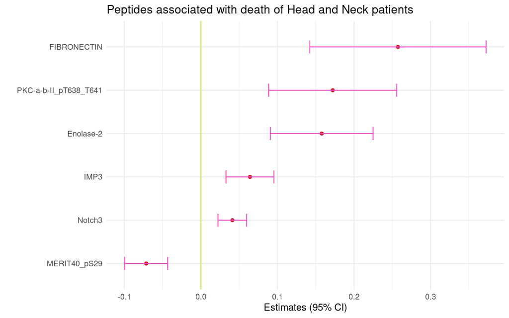

```r
forest_plot_vital <- expression_meta_data_lm_vital_estimates_clean |>
  filter(is_significant == "yes") |>
  ggplot(mapping = aes(x = estimate,
                       y = fct_reorder(.f = peptide_target,
                                       .x = estimate))) +
  geom_point(color = "#d11f2b") +
  geom_vline(xintercept = 0,
             color = "#beeb4c",
             size = 1,
             alpha = 0.5) +
  geom_errorbarh(mapping = aes(xmin = conf.low,
                               xmax = conf.high),
                 size = 0.5,
                 height = 0.3,
                 color = "#eb4cbe") +
  theme_minimal() +
  theme(plot.title = element_text(hjust = 0)) +
  labs(title = "Peptides associated with death of Head and Neck patients",
       x = "Estimates (95% CI)",
       y = "")

forest_plot_vital
```

```r
ggsave(filename = "06_analysis_lm_forest_plot.png",
       plot = forest_plot_vital,
       device = "png",
       path = "../results/images")
```

## Volcano plot

Creating a volcano plot to see up- and down regulated proteins.

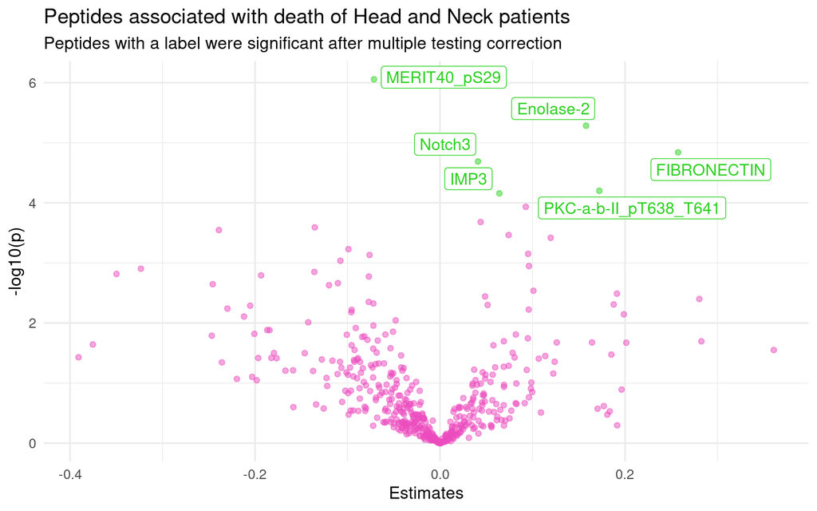

```r
volcano_plot_vital <- expression_meta_data_lm_vital_estimates_clean |>
  ggplot(mapping = aes(x = estimate,
                       y = -log10(p.value),
                       color = is_significant)) +
  geom_point(alpha = 0.5) +
  scale_color_manual(values = c("yes" =  "#2bd11f",
                                "no" ="#eb4cbe")) +
  geom_label_repel(aes(label = label),
                   size = 4,
                   max.overlaps = 25) +
  labs(title = "Peptides associated with death of Head and Neck patients",
       subtitle = "Peptides with a label were significant after multiple testing correction",
       x = "Estimates",
       y = "-log10(p)") +
  theme_minimal(base_size = 12) +
  theme(plot.title = element_text(hjust = 0),
        plot.subtitle = element_text(hjust = 0),
        legend.position = "none")

volcano_plot_vital
```

```r
ggsave(filename = "06_analysis_lm_volcano_vital.png",
       plot = volcano_plot_vital,
       device = "png",
       path = "../results/images")
```

# Analysis: Visual

## **Loading libraries**

```r
library("tidyverse")
library("ggplot2")
library("here")
```

## Loading data

```r
expression_meta_data_aug <- read_tsv(file = here("data/03_expression_meta_data_aug.tsv.gz"))
```

## **Exploring the survival of each gender**

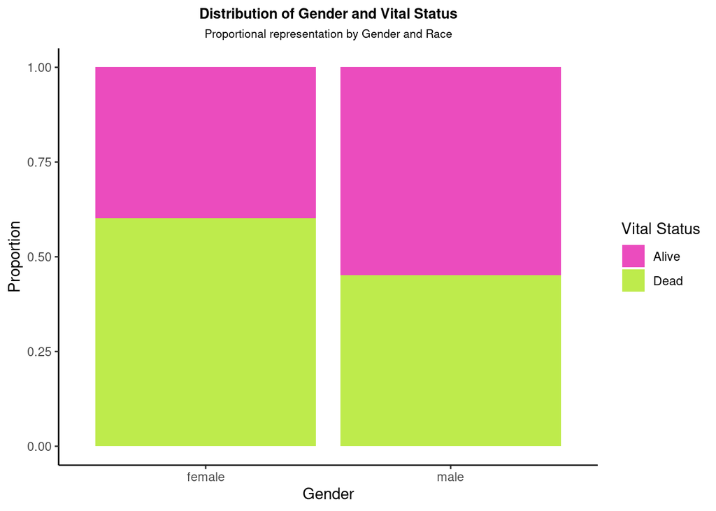

```r
#| label: "survival-between-genders-barplot-07"

barplot_vital_status_genders <- expression_meta_data_aug |>
  ggplot(mapping = aes(x = gender,
                       fill = vital_status)) +
  geom_bar(position = "fill") +
  scale_fill_manual(values = c("Alive" = "#eb4cbe",
                               "Dead" = "#beeb4c")) +
  labs(x = "Gender",
       y = "Proportion",
       title = "Distribution of Gender and Vital Status",
       subtitle = "Proportional representation by Gender and Race",
       fill = "Vital Status") +
  theme_classic() +
  theme(plot.title = element_text(size = 10, hjust = 0.5, face = "bold"),
        plot.subtitle = element_text(size = 8, hjust = 0.5),
        legend.position = "right")

barplot_vital_status_genders
```

```r
ggsave(filename = "barplot_vital_status_genders.png",
       plot = barplot_vital_status_genders,
       device = "png",
       path = "../results/images")
```

The barplot visualizes the proportion of the vital status distributed between the two genders. The position = fill in geom_bar computes the proportion and thus allows for direct comparison between the two genders. It does though not reveal absolute numbers. The barplot indicates that the proportion of dead patients is higher within the female patients.

## Exploring the vital status between different races

With a facet on each race, we can visually interpret any deviations in vital status between the different races and still keep the distributions on gender

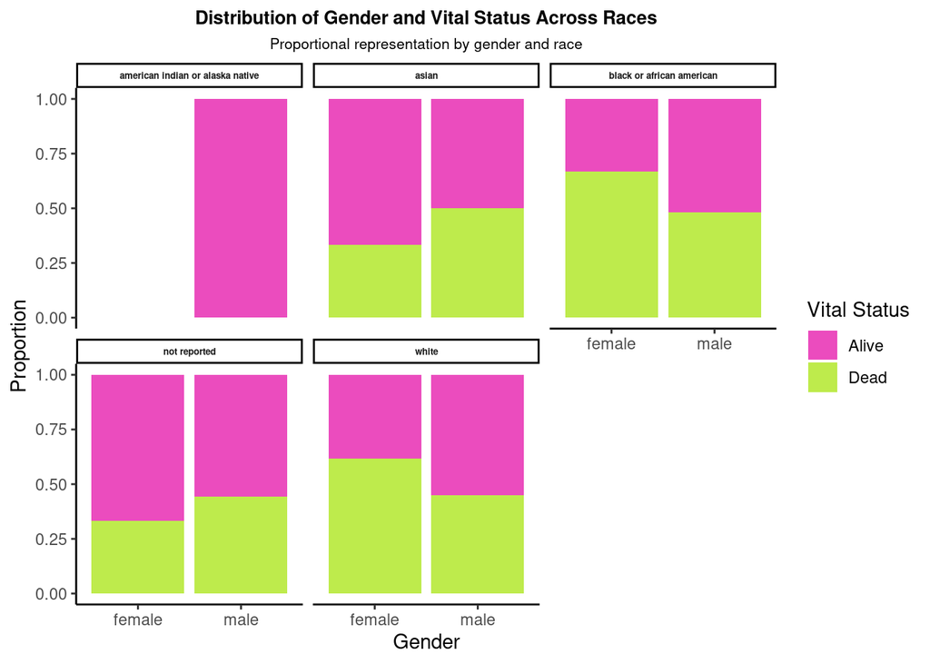

```r
#| label: "survival-between-genders-and-races-barplot-07"

barplot_vital_status_genders_facet_races <- expression_meta_data_aug |>
  ggplot(mapping = aes(x = gender, fill = vital_status)) +
  geom_bar(position = "fill")+
  scale_fill_manual(values = c("Alive" = "#eb4cbe",
                               "Dead" = "#beeb4c")) +
  facet_wrap(~race) +
  labs(x = "Gender",
       y = "Proportion",
       title = "Distribution of Gender and Vital Status Across Races",
       subtitle = "Proportional representation by gender and race",
       fill = "Vital Status") +
  theme_classic() +
  theme(plot.title = element_text(size = 10, hjust = 0.5, face = "bold"),
        plot.subtitle = element_text(size = 8, hjust = 0.5),
        strip.text = element_text(size = 5, face = "bold"))

barplot_vital_status_genders_facet_races
```

```r
ggsave(filename = "barplot_vital_status_genders_facet_races.png",
       plot = barplot_vital_status_genders_facet_races,
       device = "png",
       path = "../results/images")
```

## Exploring the effect of smoking on the vital status

Constructing a boxplot to visually and statistically interpret the relationship between “years smoked” and the vital status across the different pathological stages.

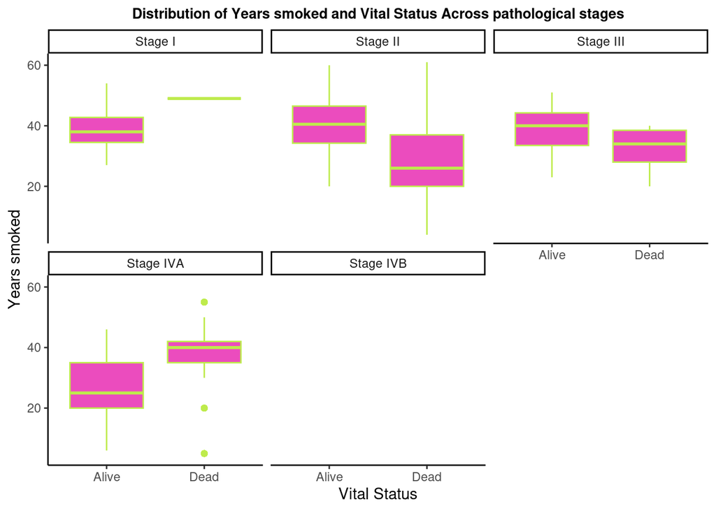

```r
#| label: "years-smoked-vital-status-07"

boxplot_years_smoked_vital_status_facet_pathological <- expression_meta_data_aug |>
  drop_na(pathologic_stage) |>
  ggplot(mapping = aes(x = vital_status,
                       y = years_smoked)) +
  geom_boxplot(fill = "#eb4cbe",
               color = "#beeb4c") +
  facet_wrap(~pathologic_stage) +
  labs(x = "Vital Status",
       y = "Years smoked",
       title = "Distribution of Years smoked and Vital Status Across pathological stages",
       fill = "Vital Status")+
  theme_classic() +
  theme(plot.title = element_text(size = 10,
                                  hjust = 0.5,
                                  face = "bold"))

boxplot_years_smoked_vital_status_facet_pathological
```

```r
ggsave(filename = "boxplot_years_smoked_vital_status_facet_pathological.png",
       plot = boxplot_years_smoked_vital_status_facet_pathological,
       device = "png",
       path = "../results/images")
```

Apparently, no patients are recorded with years smoked = 0. We assume they are registered as NA although NA could also refer to the fact that the patients did not respond. We can quickly determine the number of patients with NA;

```r
expression_meta_data_aug |>
  filter(is.na(years_smoked)) |>
  distinct(patient_id) |>
  nrow()
```

```
[1] 265
```

And we thus see that there are actually more than half of the patients with instances of NA in the “years smoked”. The boxplot shows that for stages II and III, the surviving patients have generally smoked more years, than the dead. For stage I and IV the trend is opposite.

## Visualizing significant proteins related to vital status

As the amount of significant differentially expressed proteins between alive and dead patients were found to be a relatively low number, we can visualize their individual expression levels of each patient.

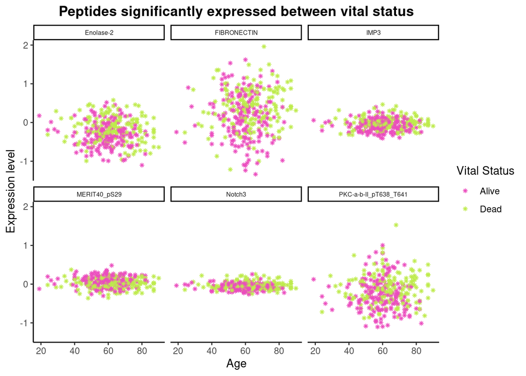

```r
#| label: "expression-of-6-significant-peptides-07"

expression_of_6_significant_pep_and_vital_status <- expression_meta_data_aug |>
  filter(peptide_target %in% c("Notch3", "FIBRONECTIN", "MERIT40_pS29","Enolase-2","PKC-a-b-II_pT638_T641","IMP3")) |>

  ggplot(mapping = aes(x = age_at_index,
                       y = expression,
                       color = vital_status
                      )) +
  geom_point( shape = 8,
              size = 1) +

  facet_wrap(~peptide_target) +

  scale_color_manual(values = c("Alive" = "#eb4cbe",
                                "Dead" = "#beeb4c")) +
  labs(x = "Age",
       y = "Expression level",
       fill = "Vital Status",
       color = "Vital Status",
       title = "Peptides significantly expressed between vital status") +
  theme_classic() +
  theme(plot.title = element_text(hjust = 0.5, face = "bold"),
        plot.subtitle = element_text(hjust = 0.5),
        strip.text = element_text(size = 6))

expression_of_6_significant_pep_and_vital_status
```

```r
ggsave(filename = "expression_of_6_significant_pep_and_vital_status.png",
       plot = expression_of_6_significant_pep_and_vital_status,
       device = "png",
       path = "../results/images")
```

**Below is a dead end:**

Trying to think of another way to display the data in a less messy way:

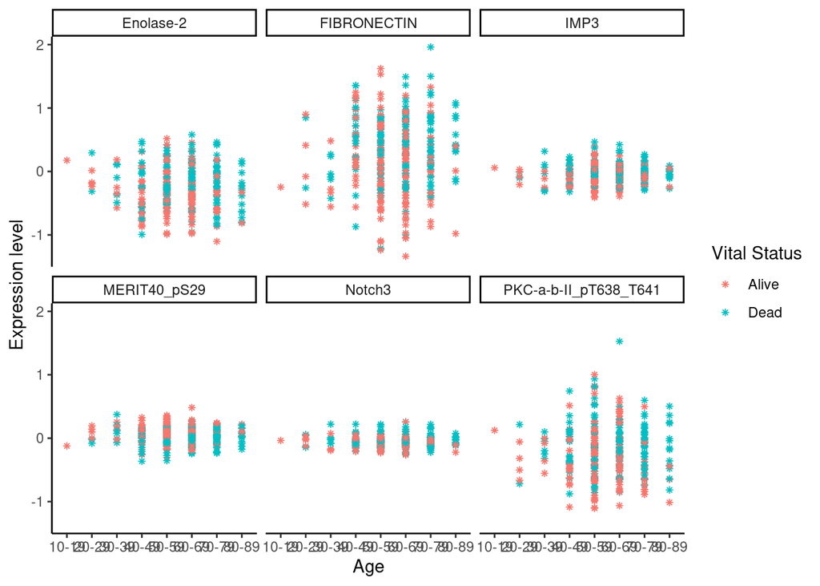

```r
expression_of_6_significant_pep_and_vital_status <- expression_meta_data_aug |>
  filter(peptide_target %in% c("Notch3", "FIBRONECTIN", "MERIT40_pS29","Enolase-2","PKC-a-b-II_pT638_T641","IMP3")) |>

  ggplot(mapping = aes(x = age_interval_10_year,
                       y = expression,
                       fill = vital_status,
                       color = vital_status)) +
  geom_point(shape = 8,
             size = 1) +
  labs(x = "Age",
       y = "Expression level",
       fill = "Vital Status",
       color = "Vital Status") +
  theme(plot.title = element_text(hjust = 0.5),
        plot.subtitle = element_text(hjust = 0.5),
        legend.title = "Vital status",
        legend.position = "right") +

  facet_wrap(~peptide_target) +
  theme_classic()

expression_of_6_significant_pep_and_vital_status
```

# Analysis: PCA on protein expression

## Load libraries

```r
library("tidyverse")
library("broom")
library("here")
```

## Loading data

```r
expression_meta_data_aug <- read_tsv(file = here("data/03_expression_meta_data_aug.tsv.gz"))

protein_data <- read_tsv(file = here("data/_raw/TCGA-HNSC.protein.tsv.gz"))

meta_data <-  read_tsv(file = here("data/01_meta_data_load.tsv.gz"))
```

## Principle component coordinates

Transposing the dataframe so the data is in the format for doing a PCA on the proteins. This is done using pivot_longer() and pivot_wider(). NA’s are dropped.

```r
protein_data_trans <- protein_data |>
  drop_na() |>
  pivot_longer(col = -1,
               names_to = "sample",
               values_to = "expression") |>
  pivot_wider(names_from = peptide_target,
              values_from = expression)

protein_data_trans
```

```
# A tibble: 354 × 218
   sample           `1433BETA` `1433EPSILON` `1433ZETA` `4EBP1` `4EBP1_pS65`
   <chr>                 <dbl>         <dbl>      <dbl>   <dbl>        <dbl>
 1 TCGA-CV-7416-01A   -0.133         -0.265       0.353   0.215       0.0329
 2 TCGA-CX-7219-01A    0.395          0.297       1.52    0.567      -0.387
 3 TCGA-CQ-7068-01A    0.151          0.100       0.820   0.989       0.380
 4 TCGA-CN-6021-01A    0.225          0.0603      0.940   0.548      -0.538
 5 TCGA-CV-7424-01A   -0.0370        -0.167       0.126   0.193      -0.244
 6 TCGA-CV-6955-01A    0.0678        -0.0428      0.379   0.368      -0.267
 7 TCGA-T2-A6WZ-01A    0.00866       -0.0626      0.374   0.129      -0.141
 8 TCGA-CV-7245-01A   -0.0883        -0.157       0.300   0.311      -0.168
 9 TCGA-CN-5355-01A    0.0539        -0.0848      1.12    1.40       -0.454
10 TCGA-CQ-6229-01A   -0.359          0.0177      0.719   1.37        0.512
# ℹ 344 more rows
# ℹ 212 more variables: `4EBP1_pT37T46` <dbl>, `4EBP1_pT70` <dbl>,
#   `53BP1` <dbl>, ACC_pS79 <dbl>, ACC1 <dbl>, ACETYLATUBULINLYS40 <dbl>,
#   ACVRL1 <dbl>, ADAR1 <dbl>, AKT <dbl>, AKT_pS473 <dbl>, AKT_pT308 <dbl>,
#   AMPKALPHA <dbl>, AMPKALPHA_pT172 <dbl>, ANNEXIN1 <dbl>, ANNEXINVII <dbl>,
#   AR <dbl>, ARAF <dbl>, ARAF_pS299 <dbl>, ARID1A <dbl>, ASNS <dbl>,
#   ATM <dbl>, BAD_pS112 <dbl>, BAK <dbl>, BAP1C4 <dbl>, BAX <dbl>, …
```

Selecting numeric values in the data for computing the PCA analysis. NA’s are dropped.

```r
pca_analysis <- protein_data_trans |>
  select_if(is.numeric) |>
  drop_na() |>
  prcomp(center = TRUE,
         scale = TRUE )
```

## Scree plot

Making a scree plot using the eigenvalues using the tidy() function. The plot is saved using ggsave().

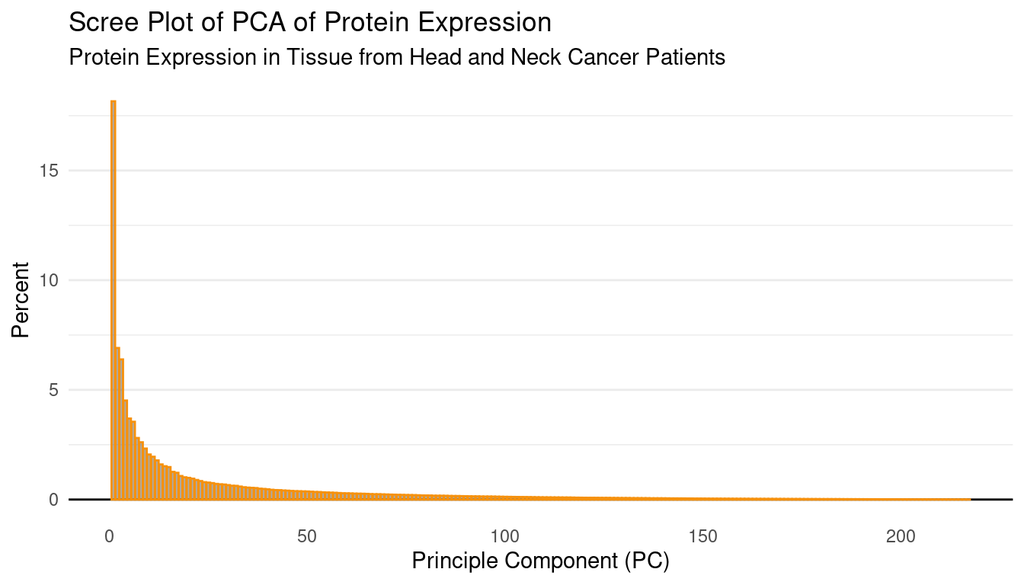

```r
scree_plot <- pca_analysis |>
  tidy("eigenvalues") |>
  mutate(percent = percent * 100) |>
  ggplot(aes(x = PC,
             y = percent)) +
  geom_hline(yintercept = 0) +
  geom_col(colour = "#f5910e",
           alpha = 0.5) +
  theme_minimal() +
  theme(panel.grid.minor.x = element_blank(),
        panel.grid.major.x = element_blank()) +
  labs(title = "Scree Plot of PCA of Protein Expression",
       subtitle = "Protein Expression in Tissue from Head and Neck Cancer Patients",
       x = "Principle Component (PC)",
       y = "Percent")

scree_plot
```

```r
ggsave(filename = "08_PCA_analysis_scree.png",
       plot = scree_plot,
       device = "png",
       path = "../results/images")
```

## Adding the meta data to the PCA analysis

Joining the data frame used in the PCA with the meta_data, to be able to color based on vital status and pathological stage. We are using left join, as we only want the meta data for the patients that we have in our PCA.

```r
protein_data_trans_metadata <- protein_data_trans |>
  left_join(y = meta_data,
            join_by(sample == sample))
```

Adding the metadata to the PC Analysis

```r
pca_analysis_aug <-  pca_analysis |>
  augment(protein_data_trans_metadata)
```

Creating labels for the PCA plot, containing the variance percentage. The value is computed using tidy().

```r
pca_axis_labels <- pca_analysis |>
  tidy("eigenvalues") |>
  mutate(label = str_c("PC", PC, ", VE = ", round(percent*100,2), "%")) |>
  pull("label")
```

## PCA plot

Plotting the PCA plot using PC1 and PC2 for the x and y axis respectively.

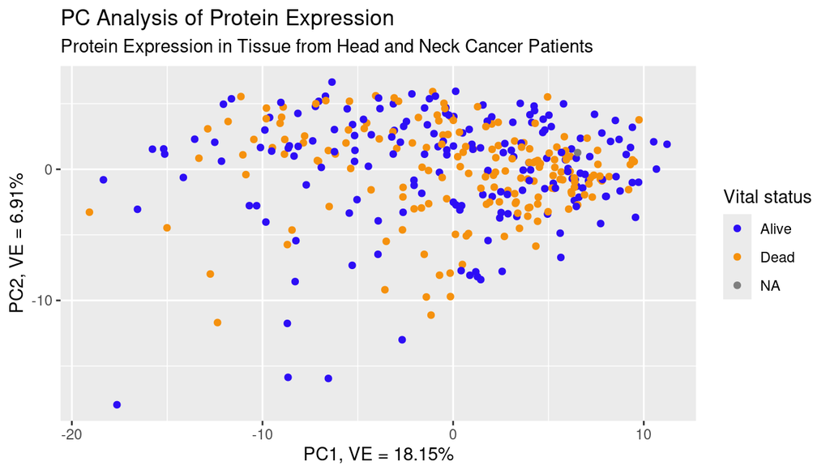

```r
pca_plot_vital <- pca_analysis_aug |>
  ggplot(aes(x = .fittedPC1,
             y = .fittedPC2,
             color = vital_status.demographic)) +
  geom_point() +
  scale_color_manual(values = c("Alive"= "#2d0ef5",
                                "Dead" = "#f5910e")) +
  labs(x = pluck(pca_axis_labels,1),
       y = pluck(pca_axis_labels,2),
       title = "PC Analysis of Protein Expression" ,
       subtitle = "Protein Expression in Tissue from Head and Neck Cancer Patients",
       color = "Vital status")

ggsave(filename = "08_PCA_analysis_PCA_vital.png",
       plot = pca_plot_vital,
       device = "png",
       path = "../results/images")

pca_plot_vital
```

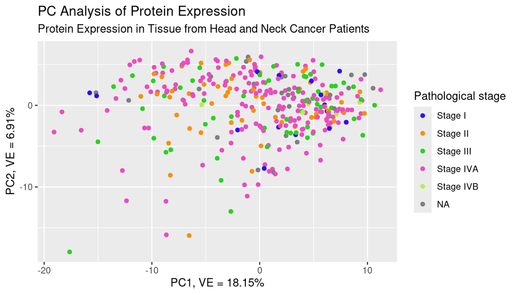

```r
pca_plot_stage <- pca_analysis_aug |>
  ggplot(aes(x = .fittedPC1,
             y = .fittedPC2,
             color = ajcc_pathologic_stage.diagnoses)) +
  geom_point() +
   scale_color_manual(values = c("Stage I"= "#2d0ef5",
                                 "Stage II" = "#f5910e",
                                 "Stage III" = "#2bd11f",
                                "Stage IVA" = "#eb4cbe",
                                "Stage IVB" = "#beeb4c")) +
  labs(x = pluck(pca_axis_labels,1),
       y = pluck(pca_axis_labels,2),
       title = "PC Analysis of Protein Expression" ,
       subtitle = "Protein Expression in Tissue from Head and Neck Cancer Patients",
       color = "Pathological stage")

ggsave(filename = "08_PCA_analysis_PCA_stage.png",
       plot = pca_plot_stage,
       device = "png",
       path = "../results/images")

pca_plot_stage
```

## Rotation matrix

```r
pca_analysis |>
  tidy(matrix = "rotation")
```

```
# A tibble: 47,089 × 3
   column      PC    value
   <chr>    <dbl>    <dbl>
 1 1433BETA     1 -0.105
 2 1433BETA     2  0.00157
 3 1433BETA     3 -0.00212
 4 1433BETA     4  0.0608
 5 1433BETA     5 -0.0322
 6 1433BETA     6  0.0136
 7 1433BETA     7 -0.0897
 8 1433BETA     8  0.00454
 9 1433BETA     9 -0.0359
10 1433BETA    10  0.0975
# ℹ 47,079 more rows
```

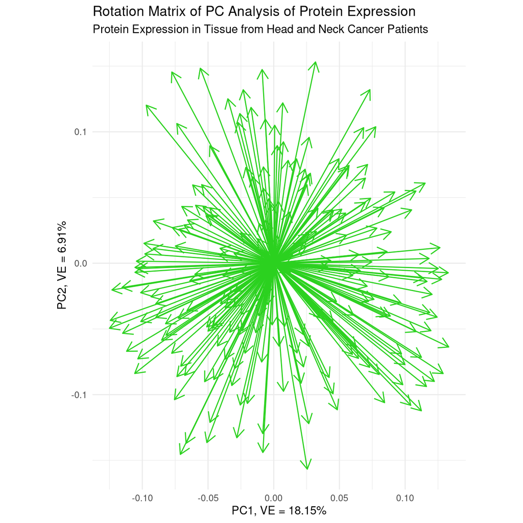

```r
arrow_style <- arrow(length = unit(0.03, "npc"),
                     ends = "first")

rotation_matrix <- pca_analysis |>
  tidy(matrix = "rotation") |>
  pivot_wider(names_from = "PC",
              names_prefix = "PC",
              values_from = "value") |>
  ggplot(aes(x = PC1,
             y = PC2)) +
  geom_segment( xend = 0,
                yend = 0,
                arrow = arrow_style,
                color = "#2bd11f") +
  coord_fixed() +
  theme_minimal() +
  labs(x = pluck(pca_axis_labels,1),
       y = pluck(pca_axis_labels,2),
       title = "Rotation Matrix of PC Analysis of Protein Expression" ,
       subtitle = "Protein Expression in Tissue from Head and Neck Cancer Patients")

rotation_matrix
```

```r
ggsave(filename = "08_PCA_analysis_RM.png",
       plot = rotation_matrix,
       device = "png",
       path = "../results/images")
```

# Analysis: Linear model on alcohol history

## Load libraries

```r
library("tidyverse")
library("broom")
library("ggthemes")
library("ggrepel")
library("here")
```

## Loading data

```r
expression_meta_data_aug <- read_tsv(file = here("data/03_expression_meta_data_aug.tsv.gz"))
```

# Linear model: alcohol history

## Selecting variables, grouping and nesting the data for the linear modelling

Selecting the variables that we want to use for the linear modeling. NA’s in “expression” are dropped.

```r
expression_meta_data_lm_alcohol <- expression_meta_data_aug |>
  select(alcohol_history_binomial,
         peptide_target,
         expression) |>
   drop_na(expression)

expression_meta_data_lm_alcohol
```

```
# A tibble: 161,195 × 3
   alcohol_history_binomial peptide_target expression
                      <dbl> <chr>               <dbl>
 1                        0 1433BETA          -0.0974
 2                        0 1433EPSILON       -0.0884
 3                        0 1433ZETA           0.295
 4                        0 4EBP1              0.236
 5                        0 4EBP1_pS65        -0.332
 6                        0 4EBP1_pT37T46     -0.209
 7                        0 4EBP1_pT70        -0.0246
 8                        0 53BP1             -0.644
 9                        0 ACC_pS79          -0.590
10                        0 ACC1              -0.119
# ℹ 161,185 more rows
```

```r
expression_meta_data_lm_alcohol_nested <- expression_meta_data_lm_alcohol |>
  group_by(peptide_target) |>
  nest()

expression_meta_data_lm_alcohol_nested
```

```
# A tibble: 469 × 2
# Groups:   peptide_target [469]
   peptide_target data
   <chr>          <list>
 1 1433BETA       <tibble [353 × 2]>
 2 1433EPSILON    <tibble [353 × 2]>
 3 1433ZETA       <tibble [353 × 2]>
 4 4EBP1          <tibble [353 × 2]>
 5 4EBP1_pS65     <tibble [353 × 2]>
 6 4EBP1_pT37T46  <tibble [353 × 2]>
 7 4EBP1_pT70     <tibble [353 × 2]>
 8 53BP1          <tibble [353 × 2]>
 9 ACC_pS79       <tibble [353 × 2]>
10 ACC1           <tibble [353 × 2]>
# ℹ 459 more rows
```

## Adding the linear model to the dataset

Adding the linear model to the data using mutate().

```r
expression_meta_data_lm_alcohol_nested_model <- expression_meta_data_lm_alcohol_nested |>
  mutate(model_object = map(.x = data,
                            .f = ~lm(formula = expression ~ alcohol_history_binomial,
                                   data = .x)))

expression_meta_data_lm_alcohol_nested_model
```

```
# A tibble: 469 × 3
# Groups:   peptide_target [469]
   peptide_target data               model_object
   <chr>          <list>             <list>
 1 1433BETA       <tibble [353 × 2]> <lm>
 2 1433EPSILON    <tibble [353 × 2]> <lm>
 3 1433ZETA       <tibble [353 × 2]> <lm>
 4 4EBP1          <tibble [353 × 2]> <lm>
 5 4EBP1_pS65     <tibble [353 × 2]> <lm>
 6 4EBP1_pT37T46  <tibble [353 × 2]> <lm>
 7 4EBP1_pT70     <tibble [353 × 2]> <lm>
 8 53BP1          <tibble [353 × 2]> <lm>
 9 ACC_pS79       <tibble [353 × 2]> <lm>
10 ACC1           <tibble [353 × 2]> <lm>
# ℹ 459 more rows
```

Computing the confidence intervals and p-value using tidy()

```r
expression_meta_data_lm_alcohol_nested_model_tidy <- expression_meta_data_lm_alcohol_nested_model |>
  mutate(model_object_tidy = map(.x = model_object,
                                 .f = ~ tidy(conf.int = TRUE,
                                             conf.level = 0.95,
                                             x =.x)))

expression_meta_data_lm_alcohol_nested_model_tidy
```

```
# A tibble: 469 × 4
# Groups:   peptide_target [469]
   peptide_target data               model_object model_object_tidy
   <chr>          <list>             <list>       <list>
 1 1433BETA       <tibble [353 × 2]> <lm>         <tibble [2 × 7]>
 2 1433EPSILON    <tibble [353 × 2]> <lm>         <tibble [2 × 7]>
 3 1433ZETA       <tibble [353 × 2]> <lm>         <tibble [2 × 7]>
 4 4EBP1          <tibble [353 × 2]> <lm>         <tibble [2 × 7]>
 5 4EBP1_pS65     <tibble [353 × 2]> <lm>         <tibble [2 × 7]>
 6 4EBP1_pT37T46  <tibble [353 × 2]> <lm>         <tibble [2 × 7]>
 7 4EBP1_pT70     <tibble [353 × 2]> <lm>         <tibble [2 × 7]>
 8 53BP1          <tibble [353 × 2]> <lm>         <tibble [2 × 7]>
 9 ACC_pS79       <tibble [353 × 2]> <lm>         <tibble [2 × 7]>
10 ACC1           <tibble [353 × 2]> <lm>         <tibble [2 × 7]>
# ℹ 459 more rows
```

## Wrangling the expression data estimates

```r
expression_meta_data_lm_alcohol_estimates <- expression_meta_data_lm_alcohol_nested_model_tidy |>
  unnest(model_object_tidy)

expression_meta_data_lm_alcohol_estimates
```

```
# A tibble: 938 × 10
# Groups:   peptide_target [469]
   peptide_target data     model_object term        estimate std.error statistic
   <chr>          <list>   <list>       <chr>          <dbl>     <dbl>     <dbl>
 1 1433BETA       <tibble> <lm>         (Intercept)  2.11e-2    0.0114    1.84
 2 1433BETA       <tibble> <lm>         alcohol_hi…  1.04e-2    0.0146    0.714
 3 1433EPSILON    <tibble> <lm>         (Intercept)  7.69e-2    0.0190    4.06
 4 1433EPSILON    <tibble> <lm>         alcohol_hi…  8.19e-3    0.0242    0.339
 5 1433ZETA       <tibble> <lm>         (Intercept)  5.48e-1    0.0428   12.8
 6 1433ZETA       <tibble> <lm>         alcohol_hi… -8.41e-4    0.0545   -0.0154
 7 4EBP1          <tibble> <lm>         (Intercept)  5.09e-1    0.0469   10.8
 8 4EBP1          <tibble> <lm>         alcohol_hi… -1.03e-1    0.0598   -1.72
 9 4EBP1_pS65     <tibble> <lm>         (Intercept) -1.61e-1    0.0272   -5.91
10 4EBP1_pS65     <tibble> <lm>         alcohol_hi… -1.77e-2    0.0347   -0.511
# ℹ 928 more rows
# ℹ 3 more variables: p.value <dbl>, conf.low <dbl>, conf.high <dbl>
```

## Clean the data and calculating q.value

Term describes if the patient drinks alcohol. 0 = no and 1 = yes. Therefore the intercept the patient does not drink alcohol and the slope + intercept the patient does drink alcohol.

```r
expression_meta_data_lm_alcohol_estimates_clean <- expression_meta_data_lm_alcohol_estimates |>
  filter(term == "alcohol_history_binomial") |>
  select(peptide_target,
         p.value,
         estimate,
         conf.low,
         conf.high) |>
  ungroup(peptide_target)

expression_meta_data_lm_alcohol_estimates_clean
```

```
# A tibble: 469 × 5
   peptide_target p.value  estimate conf.low conf.high
   <chr>            <dbl>     <dbl>    <dbl>     <dbl>
 1 1433BETA       0.476    0.0104    -0.0183    0.0391
 2 1433EPSILON    0.735    0.00819   -0.0393    0.0557
 3 1433ZETA       0.988   -0.000841  -0.108     0.106
 4 4EBP1          0.0859  -0.103     -0.221     0.0146
 5 4EBP1_pS65     0.610   -0.0177    -0.0860    0.0506
 6 4EBP1_pT37T46  0.00416 -0.209     -0.352    -0.0666
 7 4EBP1_pT70     0.389   -0.0257    -0.0842    0.0328
 8 53BP1          0.548    0.0353    -0.0800    0.151
 9 ACC_pS79       0.130   -0.0683    -0.157     0.0203
10 ACC1           0.275   -0.0646    -0.181     0.0516
# ℹ 459 more rows
```

Adding the adjusted p-value in a new variable, q.value, and add extra variable that tells if the q-value is significant or not with alpha = 5%

```r
expression_meta_data_lm_alcohol_estimates_clean <- expression_meta_data_lm_alcohol_estimates_clean |>
  mutate(q.value = p.adjust(p = p.value),
         is_significant = case_when(q.value > 0.05 ~ "no",
                                    q.value <= 0.05 ~ "yes"),
         label = case_when(is_significant == "yes" ~ peptide_target,
                           is_significant == "no" ~ ""))

expression_meta_data_lm_alcohol_estimates_clean
```

```
# A tibble: 469 × 8
   peptide_target p.value  estimate conf.low conf.high q.value is_significant
   <chr>            <dbl>     <dbl>    <dbl>     <dbl>   <dbl> <chr>
 1 1433BETA       0.476    0.0104    -0.0183    0.0391       1 no
 2 1433EPSILON    0.735    0.00819   -0.0393    0.0557       1 no
 3 1433ZETA       0.988   -0.000841  -0.108     0.106        1 no
 4 4EBP1          0.0859  -0.103     -0.221     0.0146       1 no
 5 4EBP1_pS65     0.610   -0.0177    -0.0860    0.0506       1 no
 6 4EBP1_pT37T46  0.00416 -0.209     -0.352    -0.0666       1 no
 7 4EBP1_pT70     0.389   -0.0257    -0.0842    0.0328       1 no
 8 53BP1          0.548    0.0353    -0.0800    0.151        1 no
 9 ACC_pS79       0.130   -0.0683    -0.157     0.0203       1 no
10 ACC1           0.275   -0.0646    -0.181     0.0516       1 no
# ℹ 459 more rows
# ℹ 1 more variable: label <chr>
```

```r
expression_meta_data_lm_alcohol_estimates_clean |>
  filter(is_significant == "yes")
```

```
# A tibble: 1 × 8
  peptide_target   p.value estimate conf.low conf.high q.value is_significant
  <chr>              <dbl>    <dbl>    <dbl>     <dbl>   <dbl> <chr>
1 ANNEXINVII     0.0000880    0.109   0.0549     0.163  0.0413 yes
# ℹ 1 more variable: label <chr>
```

We have 1 protein where the expression levels are found to be significantly different between patients that drink alcohol and patients that does not.

## Volcano plot

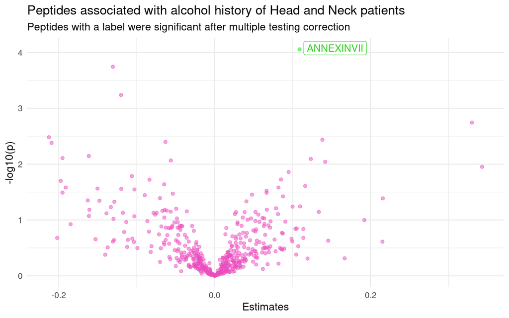

```r
volcano_plot_alcohol <- expression_meta_data_lm_alcohol_estimates_clean |>
  ggplot(mapping = aes(x = estimate,
                       y = -log10(p.value),
                       color = is_significant)) +
  geom_point(alpha = 0.5) +
  scale_color_manual(values = c("yes" =  "#2bd11f",
                                "no" ="#eb4cbe")) +
  geom_label_repel(aes(label = label),
                   size = 4,
                   max.overlaps = 25) +
  labs(title = "Peptides associated with alcohol history of Head and Neck patients",
       subtitle = "Peptides with a label were significant after multiple testing correction",
       x = "Estimates",
       y = "-log10(p)") +
  theme_minimal(base_size = 12) +
  theme(plot.title = element_text(hjust = 0),
        plot.subtitle = element_text(hjust = 0),
        legend.position = "none")

volcano_plot_alcohol
```

```r
ggsave(filename = "09_analysis_lm_volcano_alcohol.png",
       plot = volcano_plot_alcohol,
       device = "png",
       path = "../results/images")
```